# examples_0319

There are 26 tokens organized by 2 (not visible) attributes. Tokens with those attributes are categorized into subsets $A$ and $B$. Those subsets are visualized with a Venn diagram below. Each region's cardinality is shown.

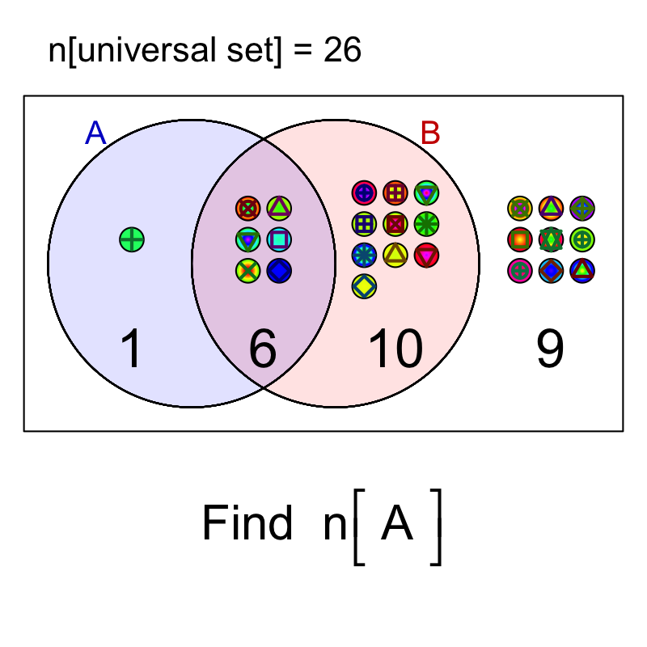

Find $n(A)$.

The answer is 7.

There are 29 tokens organized by 2 (not visible) attributes. Tokens with those attributes are categorized into subsets $A$ and $B$. Those subsets are visualized with a Venn diagram below. Each region's cardinality is shown.

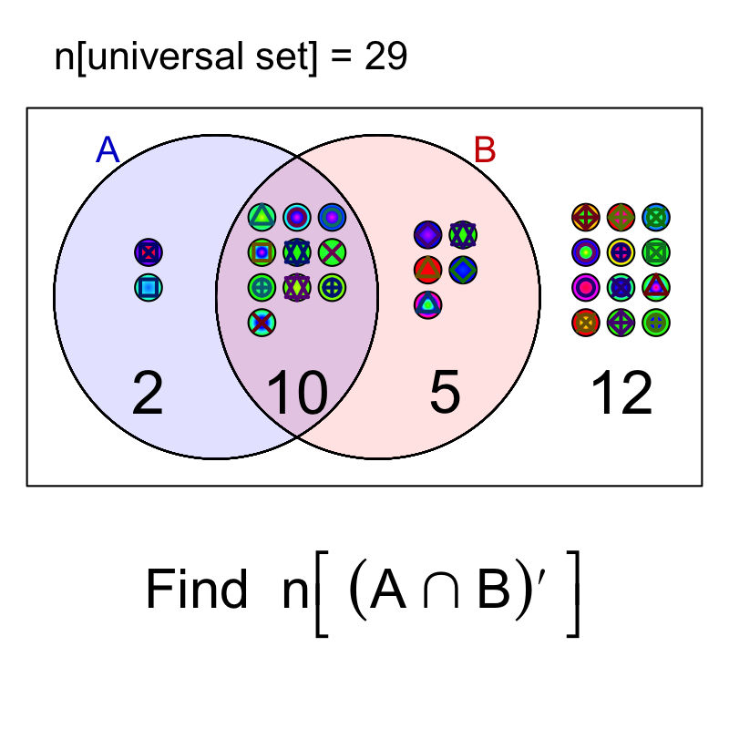

Find $n((A ∩ B)')$.

The answer is 19.

There are 23 tokens organized by 2 (not visible) attributes. Tokens with those attributes are categorized into subsets $A$ and $B$. Those subsets are visualized with a Venn diagram below. Each region's cardinality is shown.

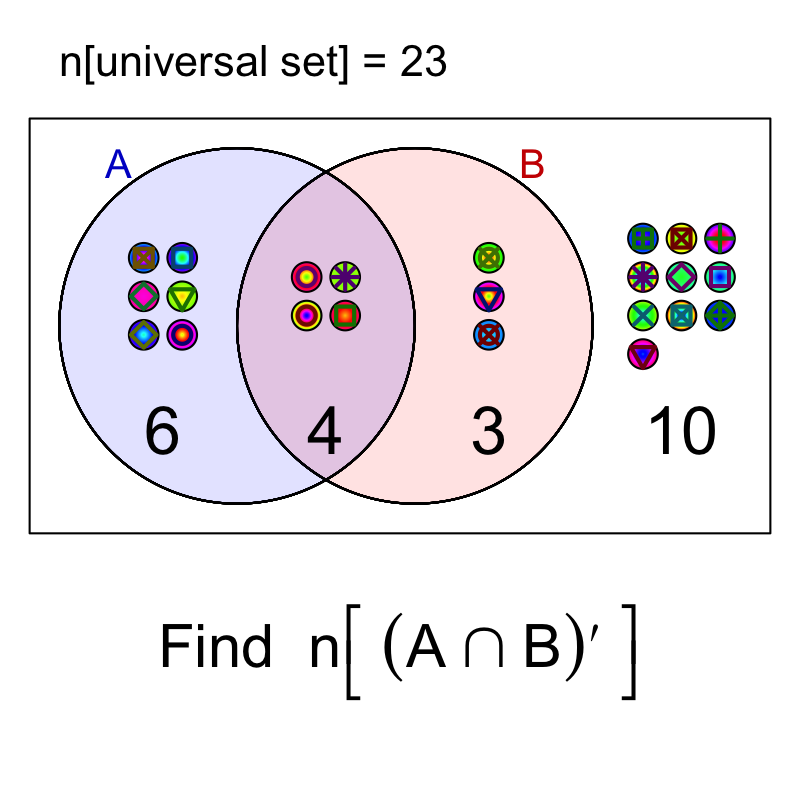

Find $n((A ∩ B)')$.

The answer is 19.

There are 27 tokens organized by 2 (not visible) attributes. Tokens with those attributes are categorized into subsets $A$ and $B$. Those subsets are visualized with a Venn diagram below. Each region's cardinality is shown.

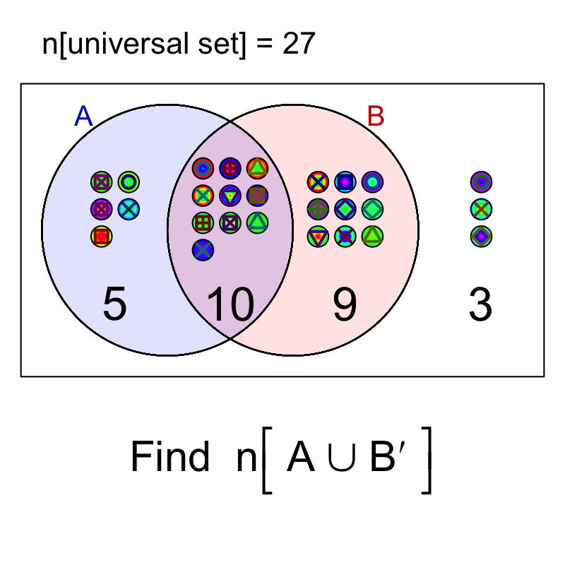

Find $n(A ∪ B')$.

The answer is 18.

There are 25 tokens organized by 2 (not visible) attributes. Tokens with those attributes are categorized into subsets $A$ and $B$. Those subsets are visualized with a Venn diagram below. Each region's cardinality is shown.

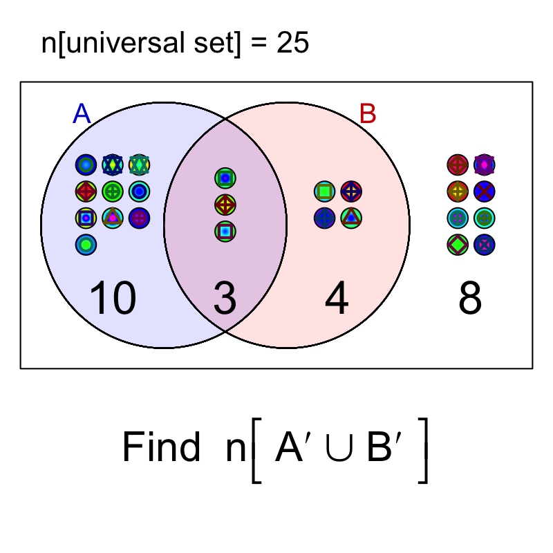

Find $n(A' ∪ B')$.

The answer is 22.

There are 23 tokens organized by 2 (not visible) attributes. Tokens with those attributes are categorized into subsets $A$ and $B$. Those subsets are visualized with a Venn diagram below. Each region's cardinality is shown.

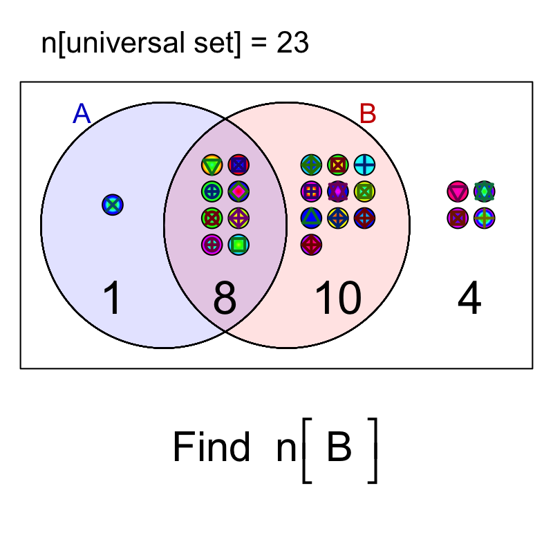

Find $n(B)$.

The answer is 18.

There are 22 tokens organized by 2 (not visible) attributes. Tokens with those attributes are categorized into subsets $A$ and $B$. Those subsets are visualized with a Venn diagram below. Each region's cardinality is shown.

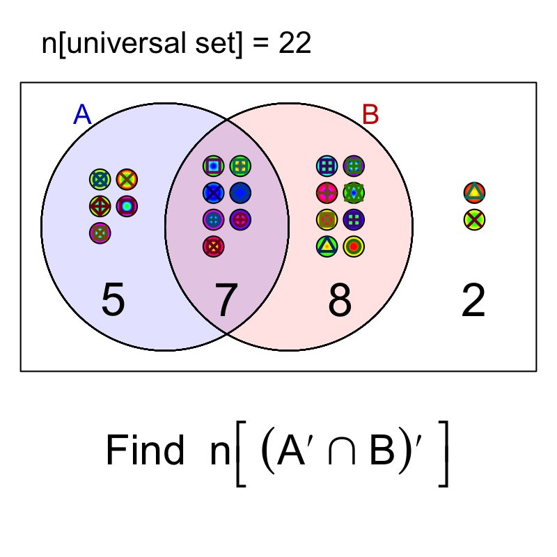

Find $n((A' ∩ B)')$.

The answer is 14.

There are 32 tokens organized by 2 (not visible) attributes. Tokens with those attributes are categorized into subsets $A$ and $B$. Those subsets are visualized with a Venn diagram below. Each region's cardinality is shown.

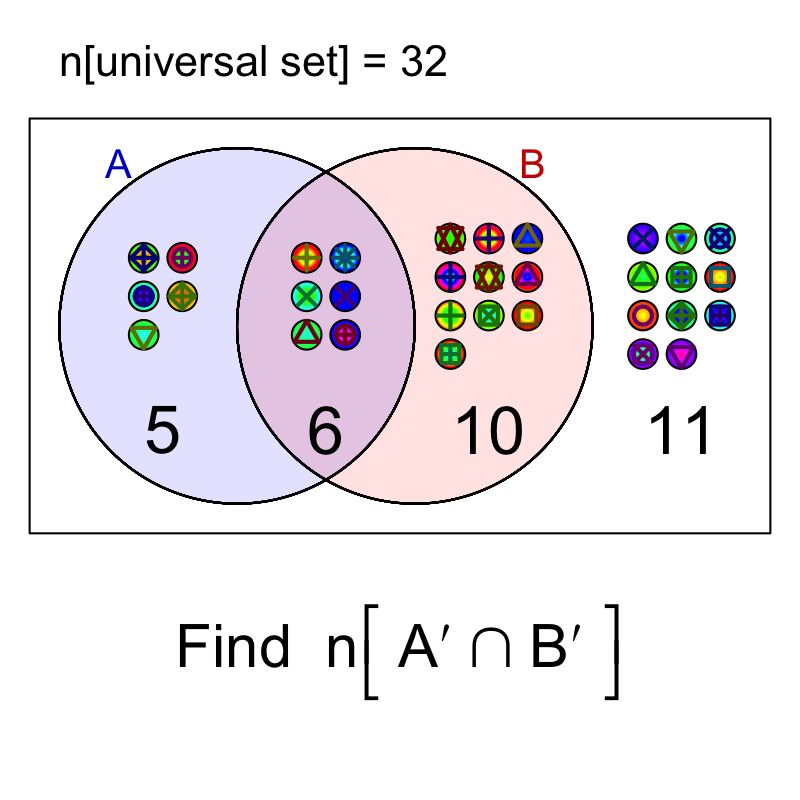

Find $n(A' ∩ B')$.

The answer is 11.

There are 19 tokens organized by 2 (not visible) attributes. Tokens with those attributes are categorized into subsets $A$ and $B$. Those subsets are visualized with a Venn diagram below. Each region's cardinality is shown.

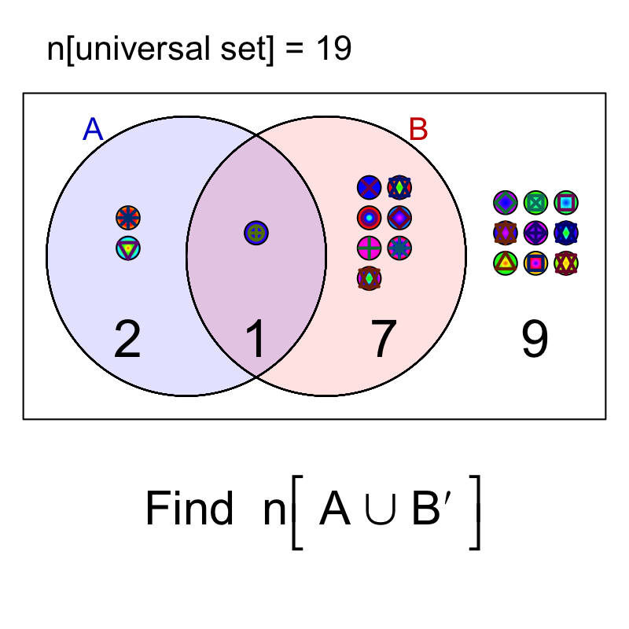

Find $n(A ∪ B')$.

The answer is 12.

There are 33 tokens organized by 2 (not visible) attributes. Tokens with those attributes are categorized into subsets $A$ and $B$. Those subsets are visualized with a Venn diagram below. Each region's cardinality is shown.

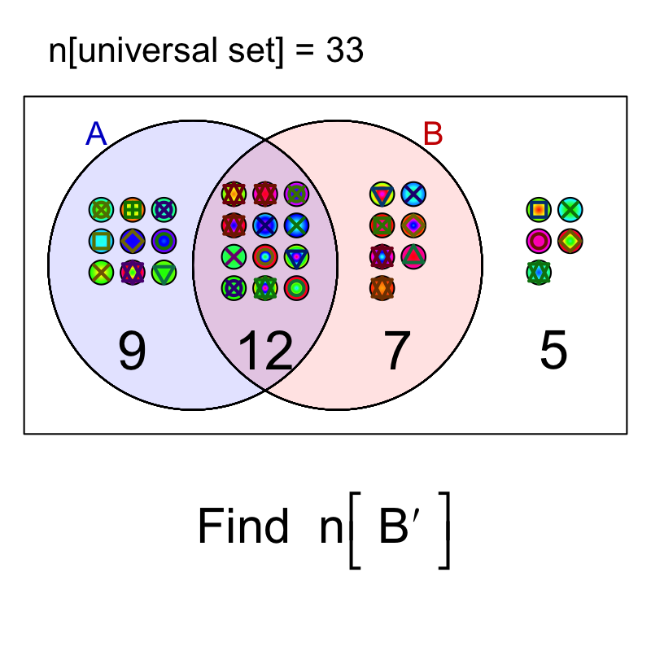

Find $n(B')$.

The answer is 14.

There are 33 tokens organized by 2 (not visible) attributes. Tokens with those attributes are categorized into subsets $A$ and $B$. Those subsets are visualized with a Venn diagram below. Each region's cardinality is shown.

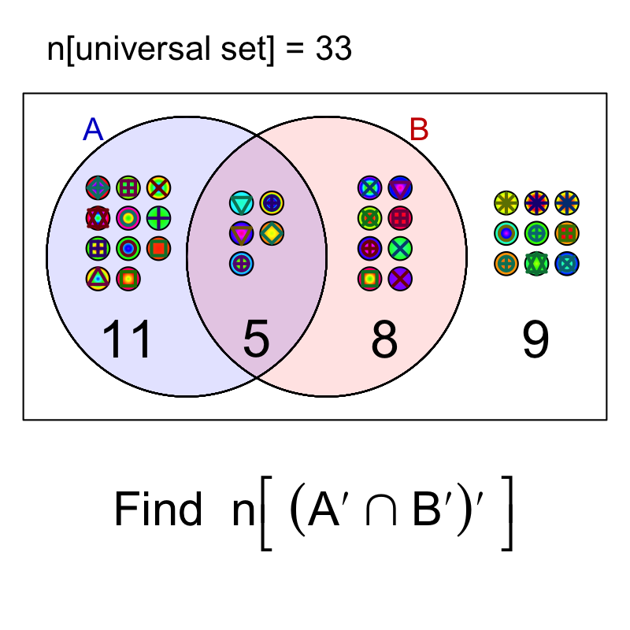

Find $n((A' ∩ B')')$.

The answer is 24.

There are 17 tokens organized by 2 (not visible) attributes. Tokens with those attributes are categorized into subsets $A$ and $B$. Those subsets are visualized with a Venn diagram below. Each region's cardinality is shown.

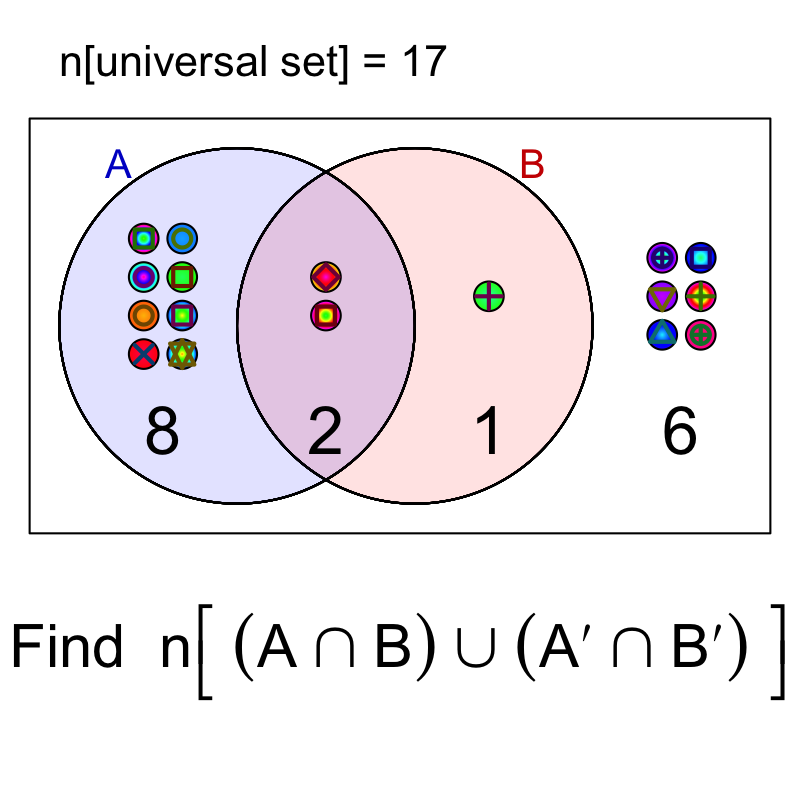

Find $n((A ∩ B)∪(A' ∩ B'))$.

The answer is 8.

There are 26 tokens organized by 2 (not visible) attributes. Tokens with those attributes are categorized into subsets $A$ and $B$. Those subsets are visualized with a Venn diagram below. Each region's cardinality is shown.

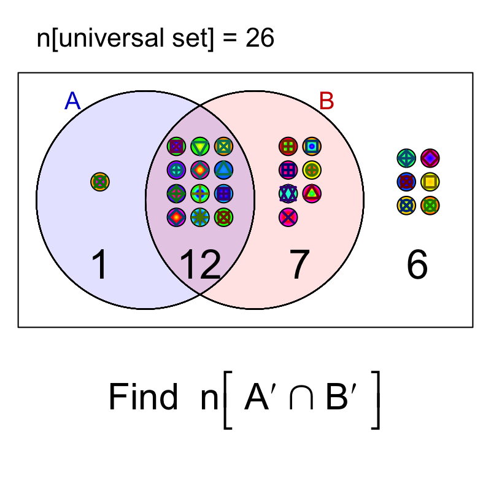

Find $n(A' ∩ B')$.

The answer is 6.

There are 24 tokens organized by 2 (not visible) attributes. Tokens with those attributes are categorized into subsets $A$ and $B$. Those subsets are visualized with a Venn diagram below. Each region's cardinality is shown.

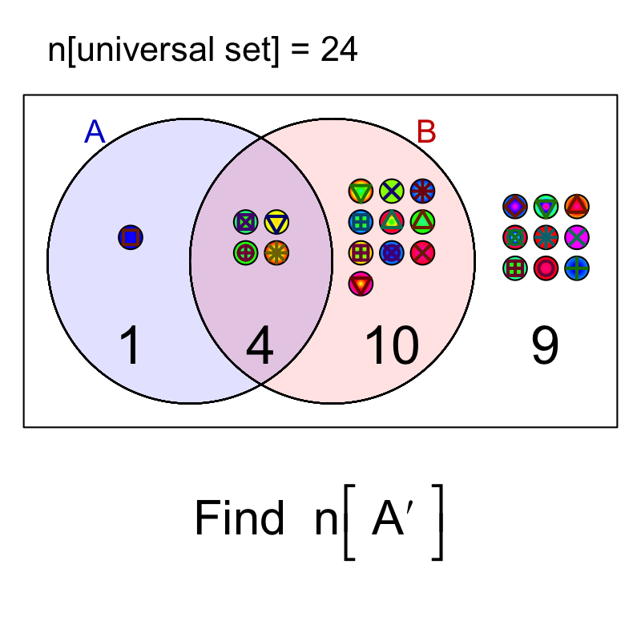

Find $n(A')$.

The answer is 19.

There are 22 tokens organized by 2 (not visible) attributes. Tokens with those attributes are categorized into subsets $A$ and $B$. Those subsets are visualized with a Venn diagram below. Each region's cardinality is shown.

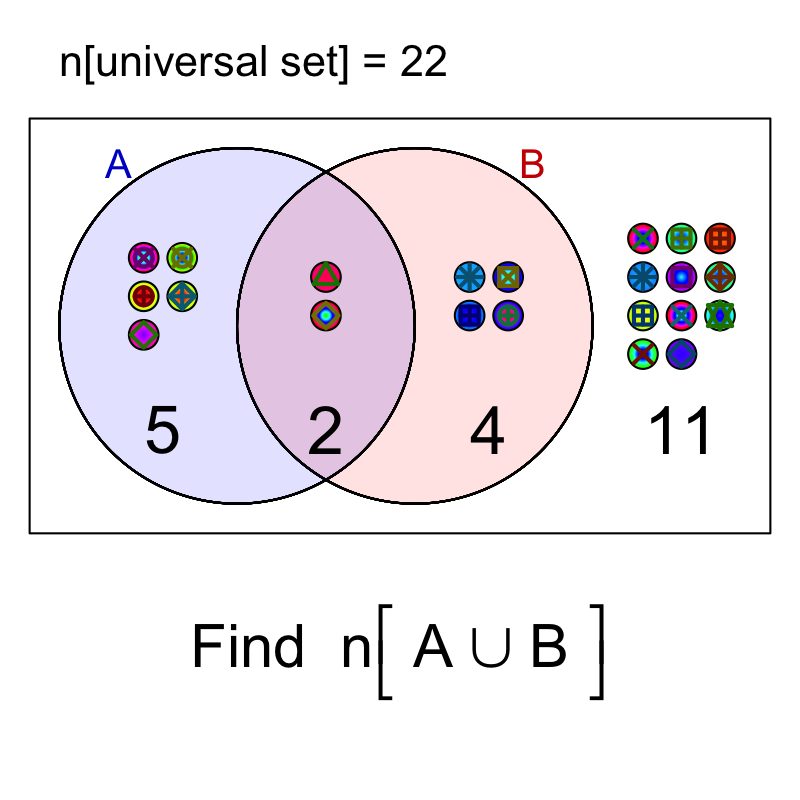

Find $n(A ∪ B)$.

The answer is 11.

There are 36 tokens organized by 2 (not visible) attributes. Tokens with those attributes are categorized into subsets $A$ and $B$. Those subsets are visualized with a Venn diagram below. Each region's cardinality is shown.

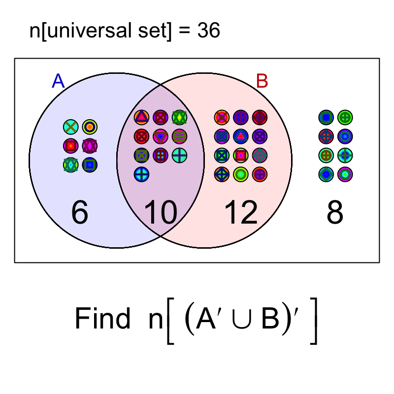

Find $n((A' ∪ B)')$.

The answer is 6.

There are 25 tokens organized by 2 (not visible) attributes. Tokens with those attributes are categorized into subsets $A$ and $B$. Those subsets are visualized with a Venn diagram below. Each region's cardinality is shown.

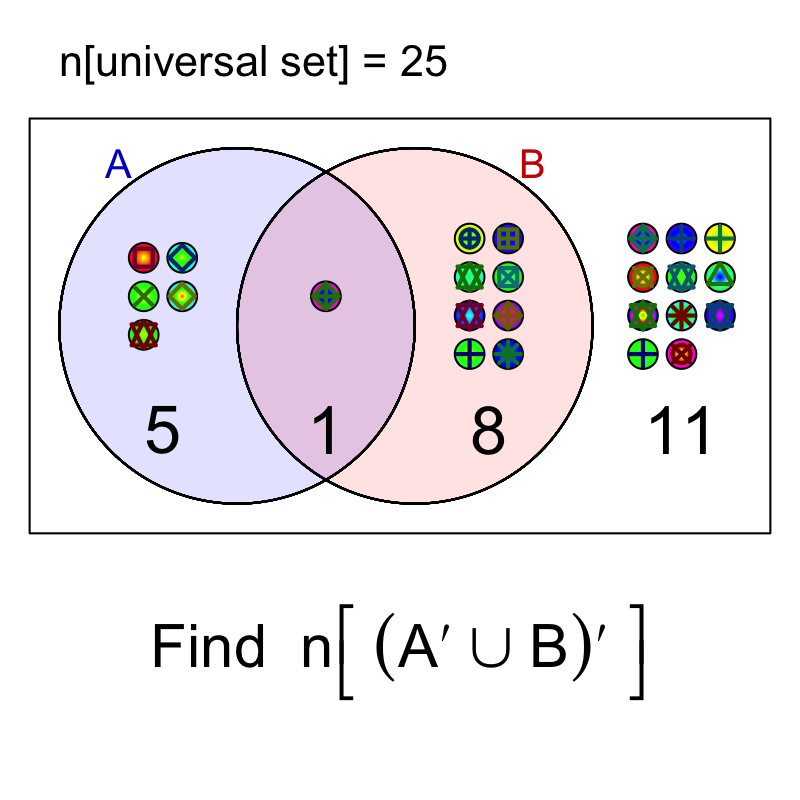

Find $n((A' ∪ B)')$.

The answer is 5.

There are 31 tokens organized by 2 (not visible) attributes. Tokens with those attributes are categorized into subsets $A$ and $B$. Those subsets are visualized with a Venn diagram below. Each region's cardinality is shown.

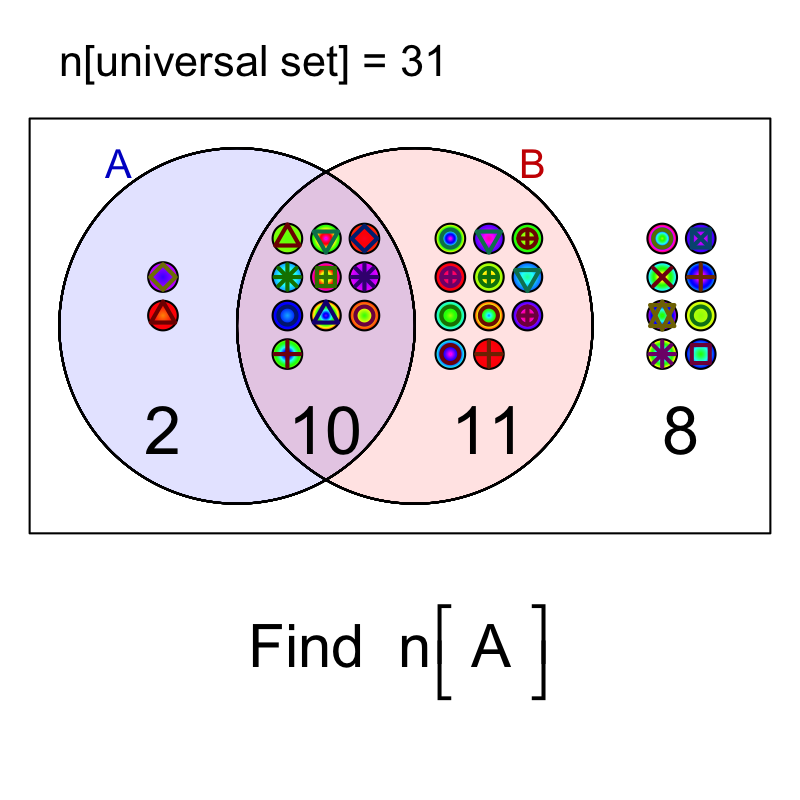

Find $n(A)$.

The answer is 12.

There are 33 tokens organized by 2 (not visible) attributes. Tokens with those attributes are categorized into subsets $A$ and $B$. Those subsets are visualized with a Venn diagram below. Each region's cardinality is shown.

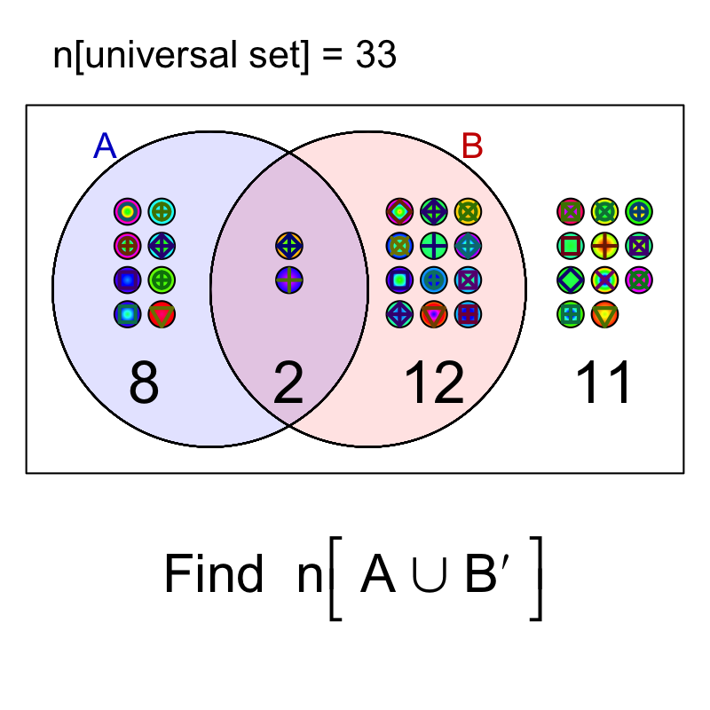

Find $n(A ∪ B')$.

The answer is 21.

There are 31 tokens organized by 2 (not visible) attributes. Tokens with those attributes are categorized into subsets $A$ and $B$. Those subsets are visualized with a Venn diagram below. Each region's cardinality is shown.

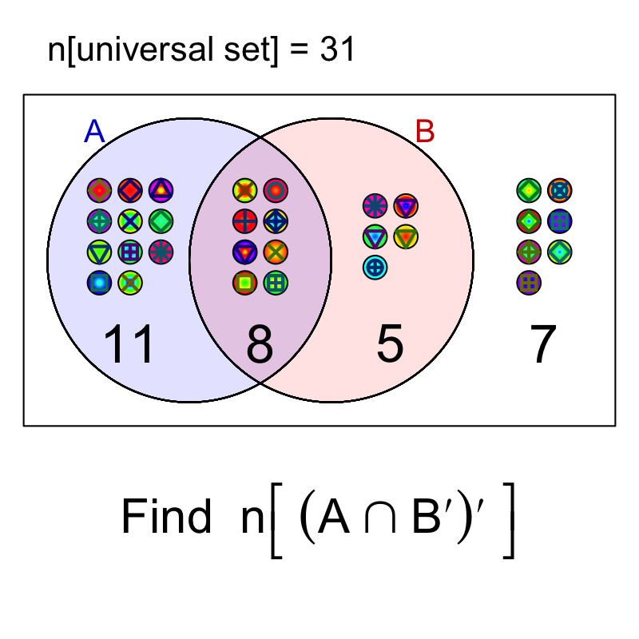

Find $n((A ∩ B')')$.

The answer is 20.

Let the cardinality of the universal set be 91.

$$n(U)=91$$

Three subsets, $A$, $B$, and $C$ are visualized with a Venn diagram below. Each region's cardinality is shown.

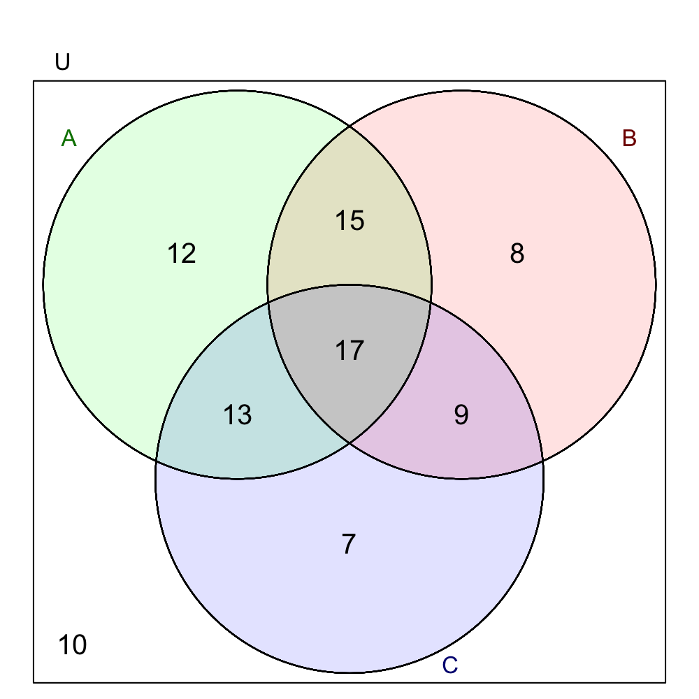

Find $n(A'\cap B' \cap C)$.

The answer is 7.

Let the cardinality of the universal set be 80.

$$n(U)=80$$

Three subsets, $A$, $B$, and $C$ are visualized with a Venn diagram below. Each region's cardinality is shown.

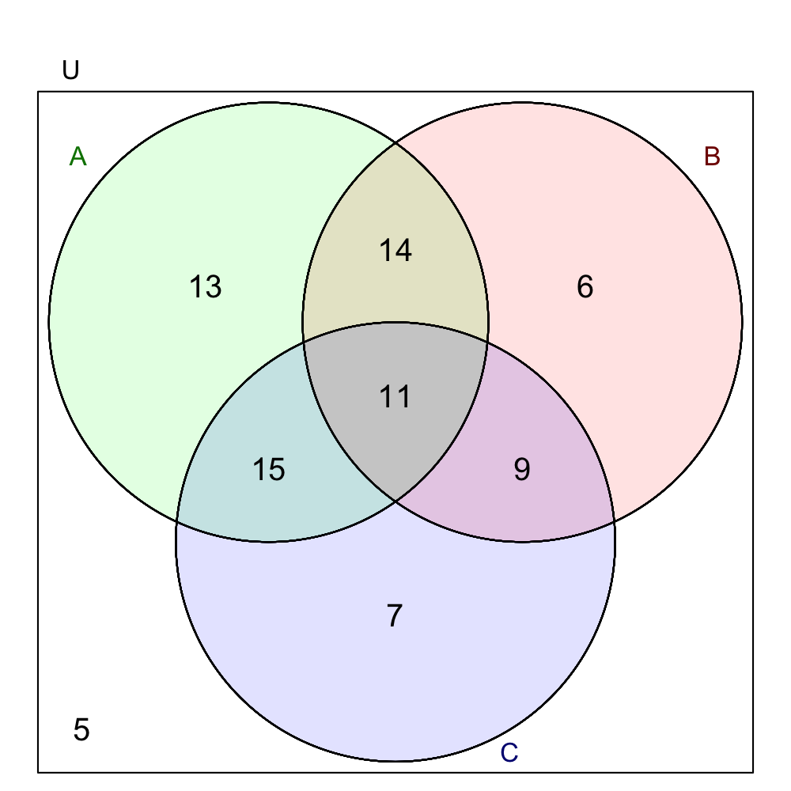

Let the cardinality of the universal set be 64.

$$n(U)=64$$

Three subsets, $A$, $B$, and $C$ are visualized with a Venn diagram below. Each region's cardinality is shown.

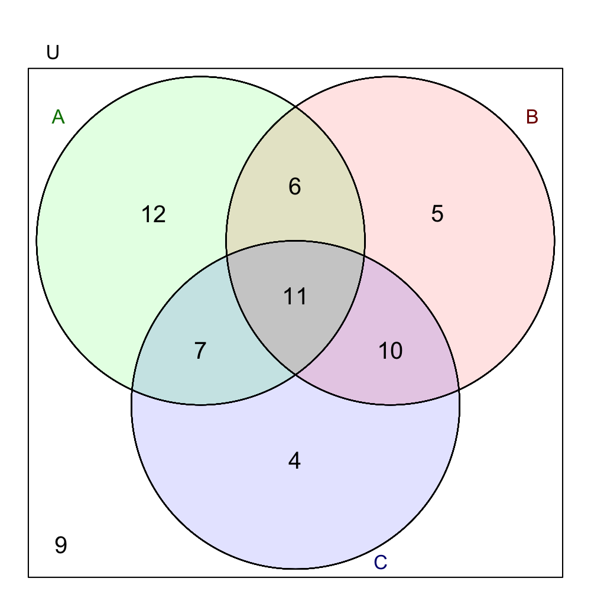

Find $n(A' \cap C')$.

The answer is 14.

Let the cardinality of the universal set be 69.

$$n(U)=69$$

Three subsets, $A$, $B$, and $C$ are visualized with a Venn diagram below. Each region's cardinality is shown.

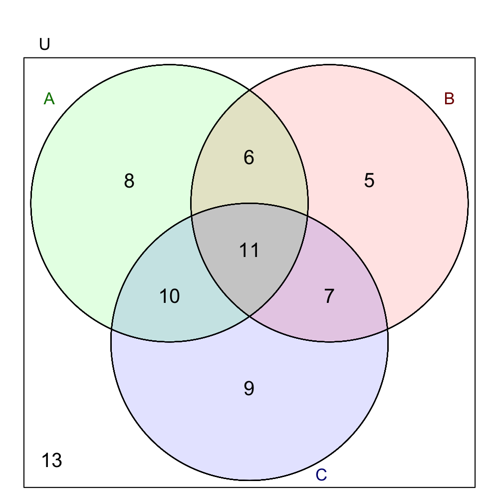

Find $n(A \cup B')$.

The answer is 57.

Let the cardinality of the universal set be 77.

$$n(U)=77$$

Three subsets, $A$, $B$, and $C$ are visualized with a Venn diagram below. Each region's cardinality is shown.

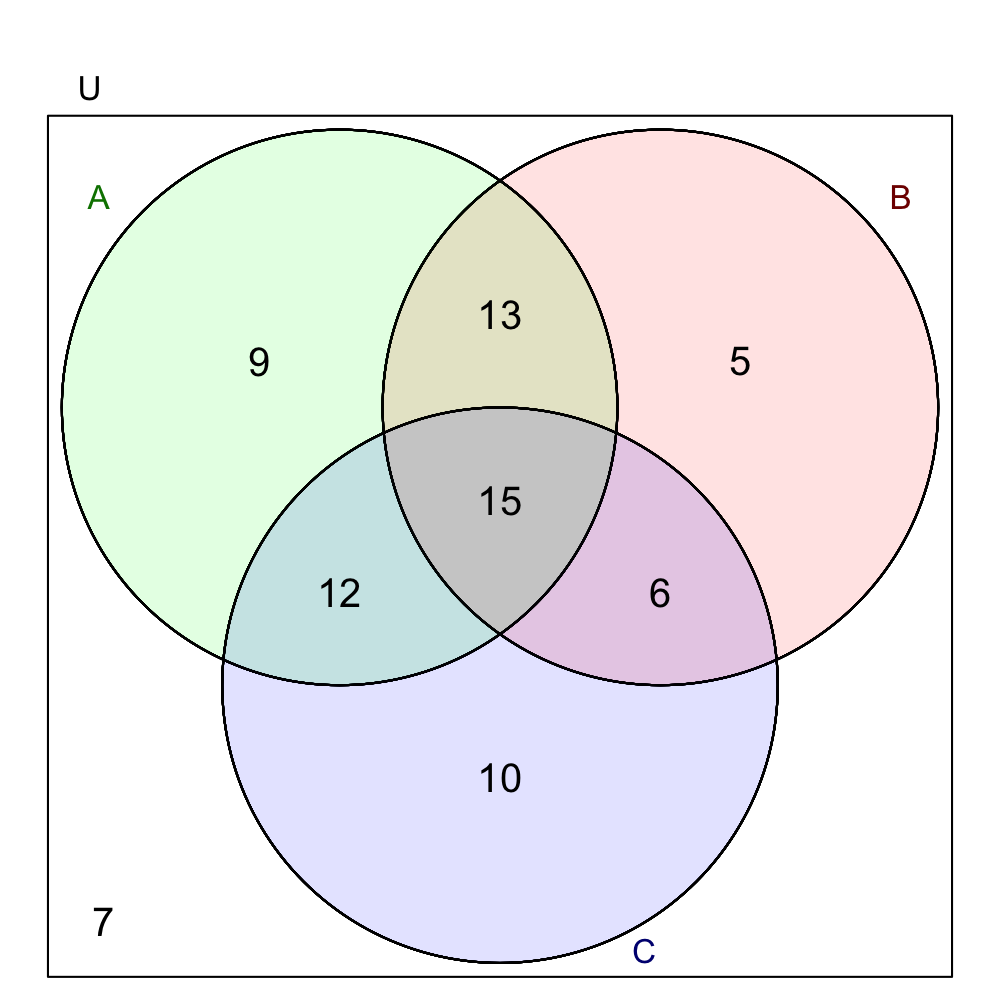

Find $n(A)$.

The answer is 49.

Let the cardinality of the universal set be 77.

$$n(U)=77$$

Three subsets, $A$, $B$, and $C$ are visualized with a Venn diagram below. Each region's cardinality is shown.

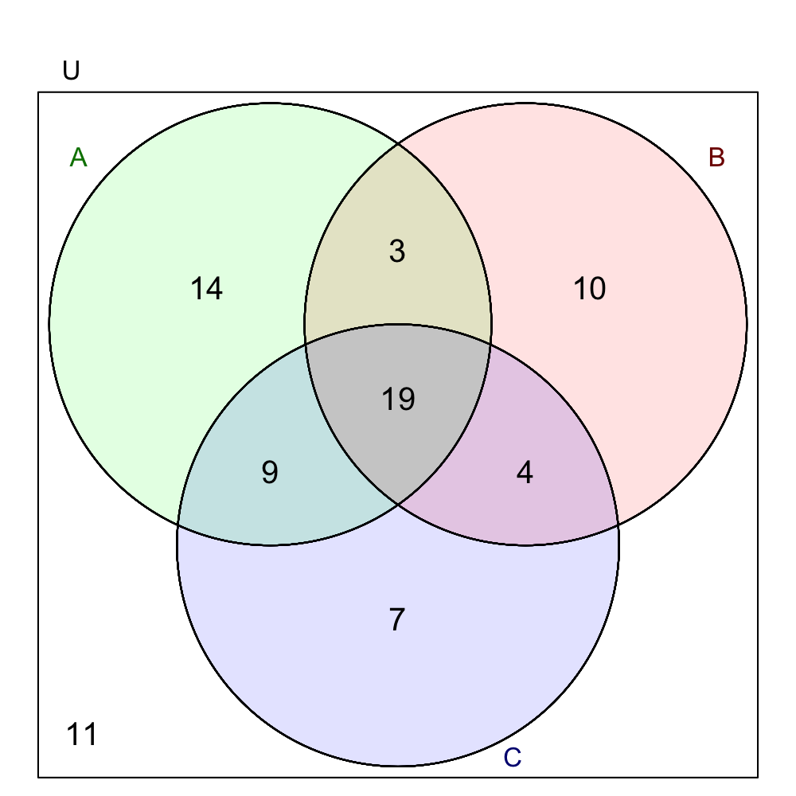

Find $n((A \cap B)')$.

The answer is 55.

Let the cardinality of the universal set be 98.

$$n(U)=98$$

Three subsets, $A$, $B$, and $C$ are visualized with a Venn diagram below. Each region's cardinality is shown.

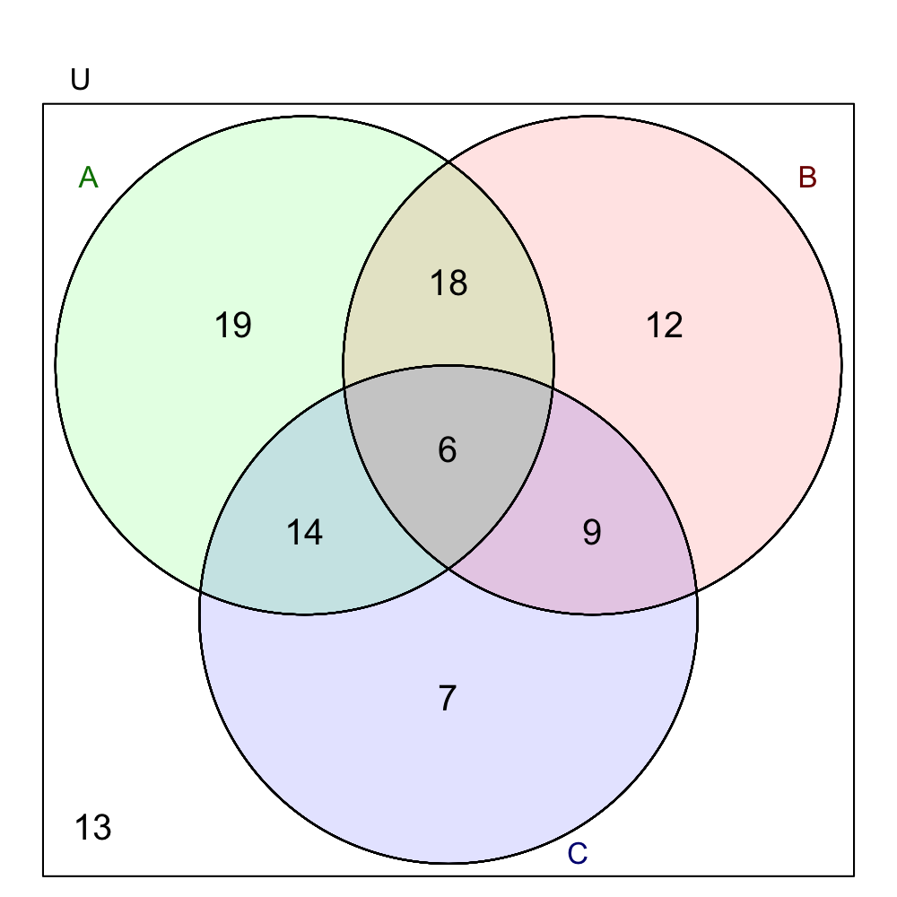

Find $n((A \cup B)')$.

The answer is 20.

Let the cardinality of the universal set be 46.

$$n(U)=46$$

Three subsets, $A$, $B$, and $C$ are visualized with a Venn diagram below. Each region's cardinality is shown.

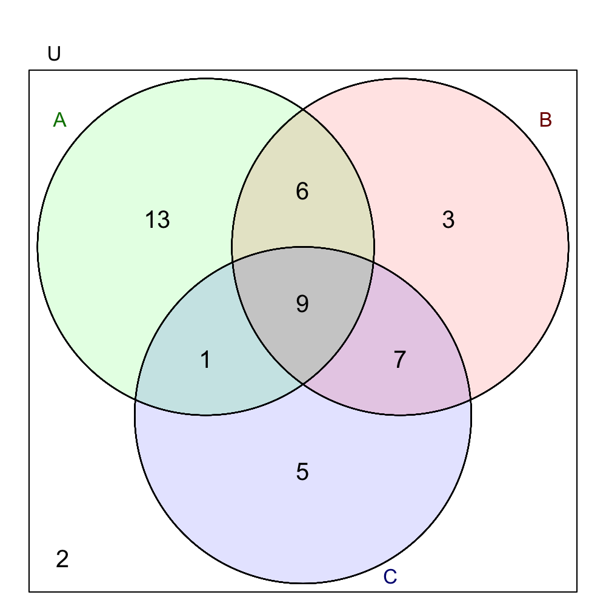

Find $n(B')$.

The answer is 21.

Let the cardinality of the universal set be 88.

$$n(U)=88$$

Three subsets, $A$, $B$, and $C$ are visualized with a Venn diagram below. Each region's cardinality is shown.

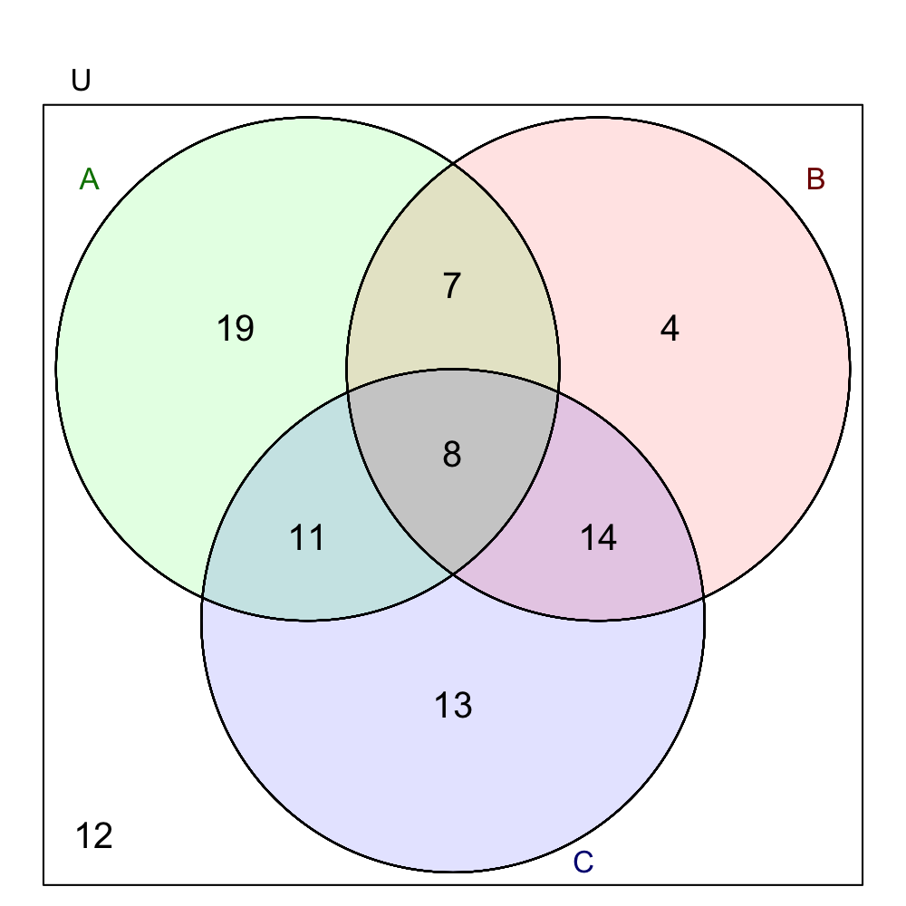

Find $n((A \cap B)')$.

The answer is 73.

Let the cardinality of the universal set be 71.

$$n(U)=71$$

Three subsets, $A$, $B$, and $C$ are visualized with a Venn diagram below. Each region's cardinality is shown.

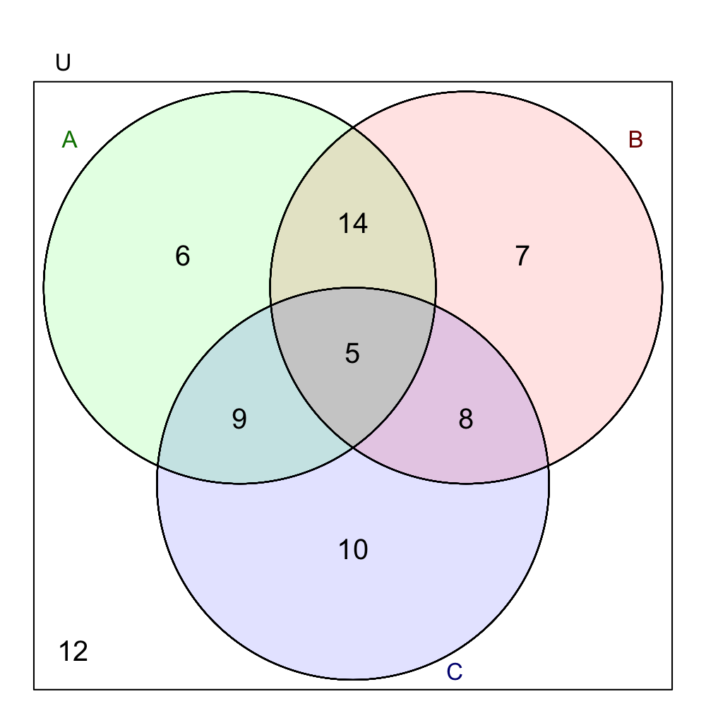

Find $n(B)$.

The answer is 34.

Let the cardinality of the universal set be 79.

$$n(U)=79$$

Three subsets, $A$, $B$, and $C$ are visualized with a Venn diagram below. Each region's cardinality is shown.

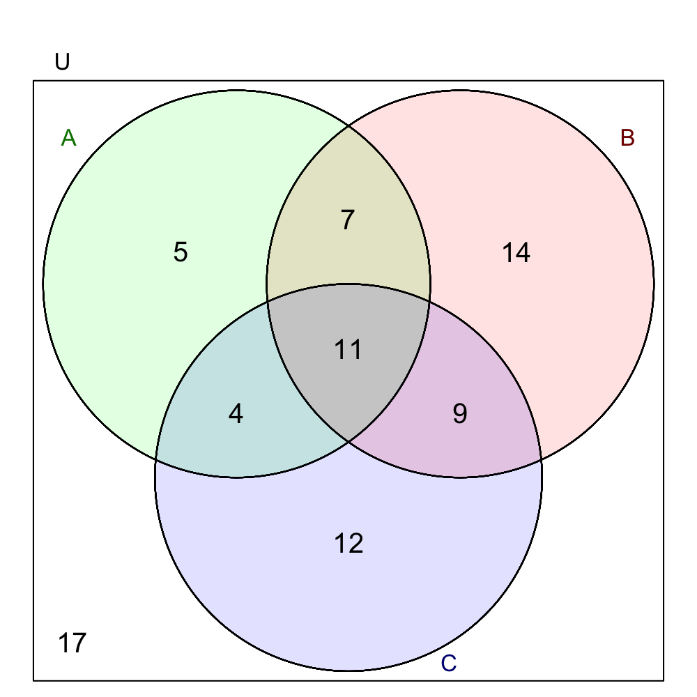

Find $n(B \cap C)$.

The answer is 20.

Let the cardinality of the universal set be 84.

$$n(U)=84$$

Three subsets, $A$, $B$, and $C$ are visualized with a Venn diagram below. Each region's cardinality is shown.

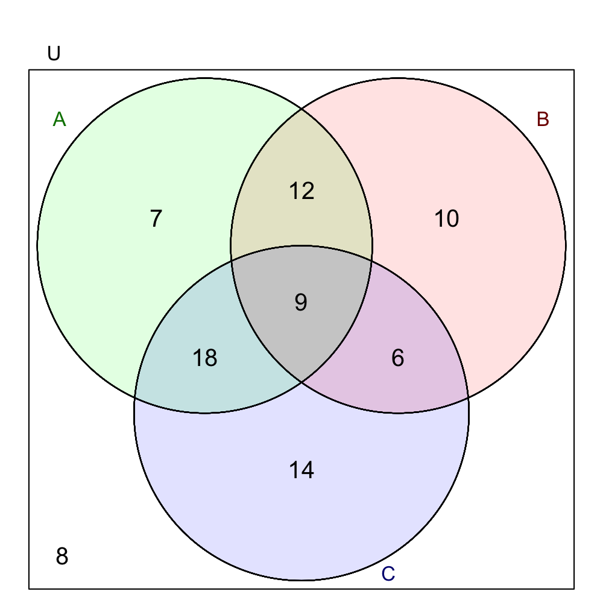

Find $n(A \cap B')$.

The answer is 25.

Let the cardinality of the universal set be 73.

$$n(U)=73$$

Three subsets, $A$, $B$, and $C$ are visualized with a Venn diagram below. Each region's cardinality is shown.

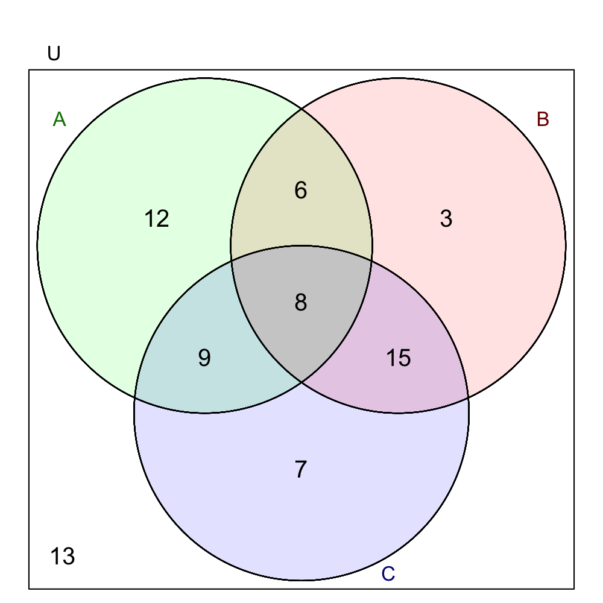

Find $n(B \cup C')$.

The answer is 57.

Let the cardinality of the universal set be 82.

$$n(U)=82$$

Three subsets, $A$, $B$, and $C$ are visualized with a Venn diagram below. Each region's cardinality is shown.

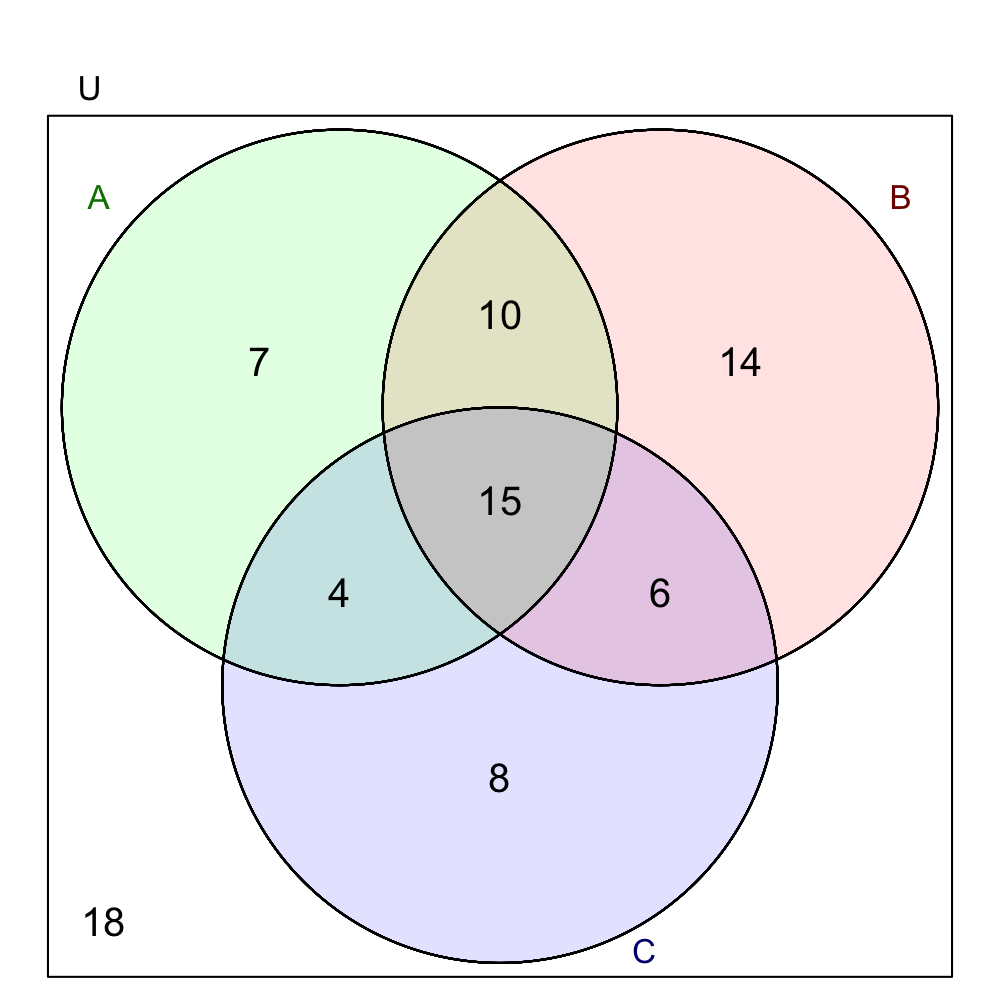

Find $n((A \cup B)')$.

The answer is 26.

Let the cardinality of the universal set be 77.

$$n(U)=77$$

Three subsets, $A$, $B$, and $C$ are visualized with a Venn diagram below. Each region's cardinality is shown.

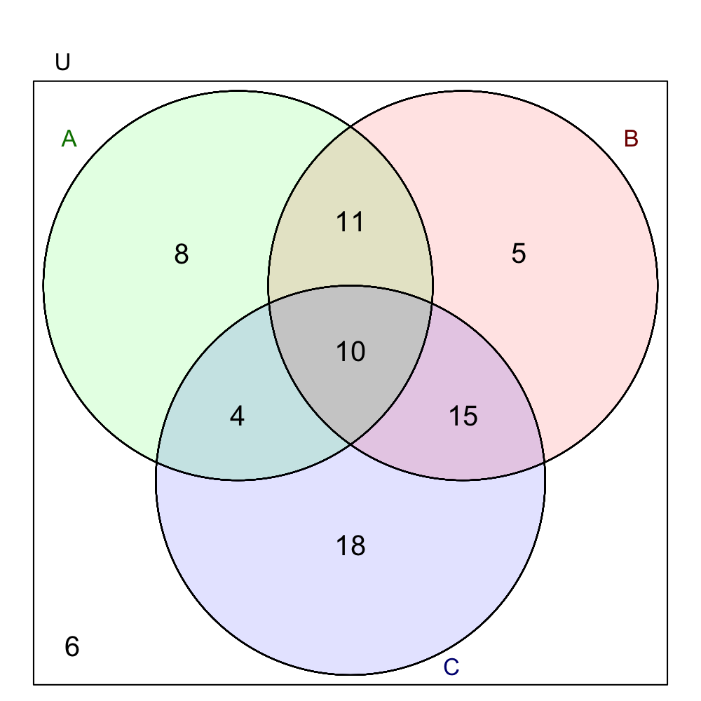

Find $n(A'\cap B \cap C')$.

The answer is 5.

Let the cardinality of the universal set be 95.

$$n(U)=95$$

Three subsets, $A$, $B$, and $C$ are visualized with a Venn diagram below. Each region's cardinality is shown.

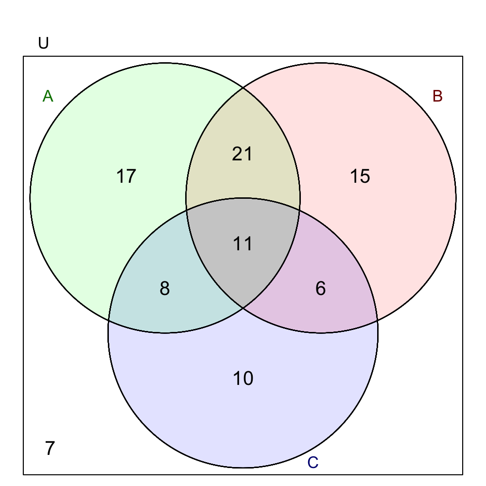

Find $n(A' \cup B')$.

The answer is 63.

Let the cardinality of the universal set be 62.

$$n(U)=62$$

Three subsets, $A$, $B$, and $C$ are visualized with a Venn diagram below. Each region's cardinality is shown.

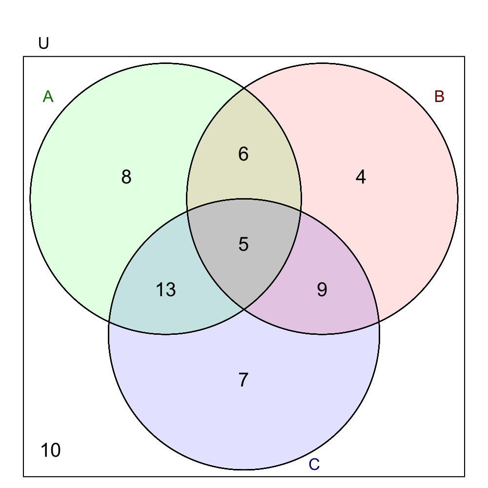

Find $n(A\cap B \cap C')$.

The answer is 6.

Let the cardinality of the universal set be 85.

$$n(U)=85$$

Three subsets, $A$, $B$, and $C$ are visualized with a Venn diagram below. Each region's cardinality is shown.

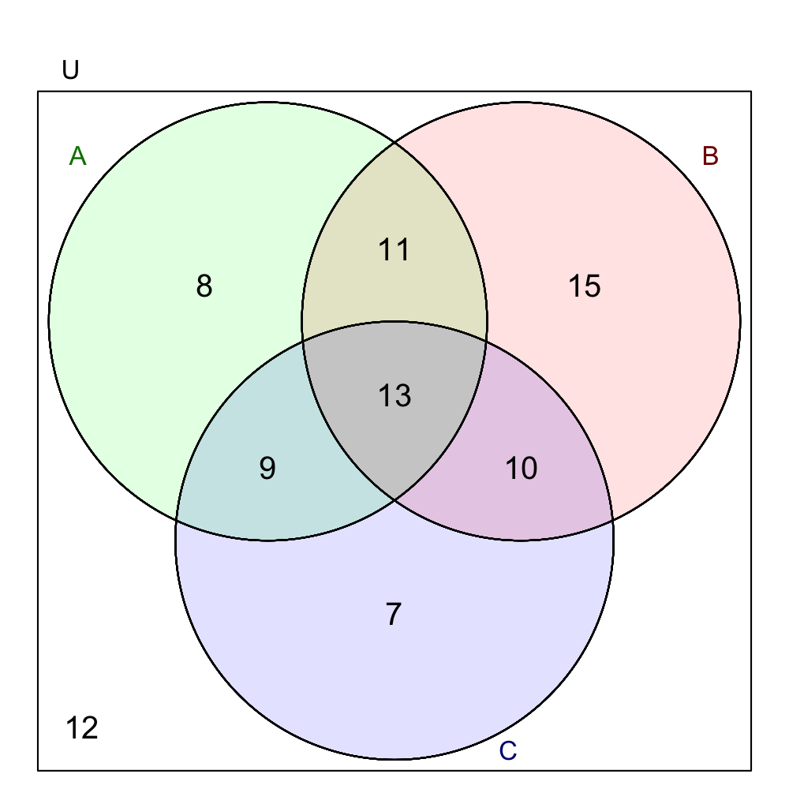

Find $n(A \cup B)$.

The answer is 66.

Let the cardinality of the universal set be 65.

$$n(U)=65$$

Three subsets, $A$, $B$, and $C$ are visualized with a Venn diagram below. Each region's cardinality is shown.

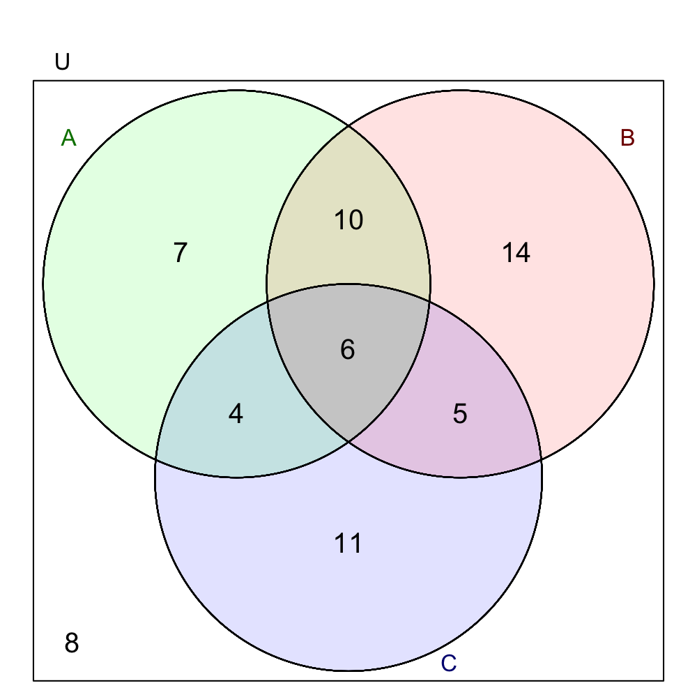

Find $n(A' \cap B \cap C)$.

The answer is 5.

Let the cardinality of the universal set be 65.

$$n(U)=65$$

Three subsets, $A$, $B$, and $C$ are visualized with a Venn diagram below. Each region's cardinality is shown.

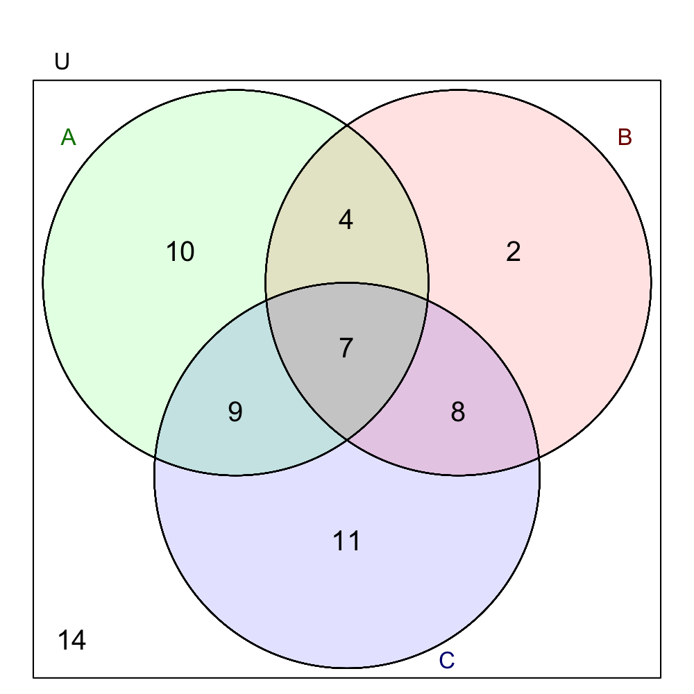

Find $n(B' \cap C')$.

The answer is 24.